# Age Trajectory Analysis Summary

SDS, RKJ

2026-07-17

# **Load Data**

```r
# Load candidate list
candidates = fread("data/results/manuscript/dmp.dmr.cpgs.csv", sep = ",",
                   keepLeadingZeros = TRUE)

# cpg to dmr map - for summarizing DMR-level overlap, need to add DMR_id to candidates
dmr = read.csv("data/results/manuscript/dmr_meta_teddy_granges_red_df.csv")
dmr$dmrid_red = gsub("_","",dmr$dmrid_red)
dmr_map = dmr[,c("cpg","dmrid_red")]
dmr_map = separate_longer_delim(dmr_map, col="cpg",",")
candidates = left_join(candidates, dmr_map, by = "cpg")

# cpg annotation for whether DNAm changes with age
age_teddy = readRDS("data/teddy/TEDDYarrays/CpG_info/CpG_info_subj_int_anno.rds")

# Load input into summary measures (normalized M-values)
dnam <- load(
  "data/teddy/TEDDYarrays/preprocessing-dnam/mSet-norm-batch-mean-plate-row.Rdata")
dnam <- get(dnam)
rm(mSet.norm.mean.plate_row)

# Load sample mapping
pheno = read.csv("raw/TEDDYarrays_v2/NorrisAncillary_NCC_sample_mapping_v2.csv") %>%
  dplyr::mutate(rgName = paste0(beadchip_barcode, "_", beadchip_position))

# Load pheno for analysis
pheno_analysis <- read_csv("data/teddy/TEDDYarrays/subject_pheno_204.csv")

# Load list of samples for analysis
for_analysis <- read_csv(
  "data/teddy/TEDDYarrays/samples-for-analysis.csv")

# horvath clock
load_DNAm_Clocks_data()
horvath = coefHorvath[-1,] #removed "intercept" first row, now 353 rows = correct for Horvath clock

# External functions
source("/Users/johnrand/repos/explore_matprot/TEDDYcode/2-analysis/Functions/getBeta.R")
```

# **Overview**

Purpose: To identify DNAm changes over time/age in TEDDY children. This information will be used to characterize candidates of the maternal T1D effect in the Exploring Maternal Protection project. We will summarize 1) EWAS, 2) candidates, 3) meta-stable epialleles

After accounting for inter-individual differences in DNAm starting place (intercept) and change with age (slope), we’re interested in interpreting the fixed effect of age, which represents the average change in DNAm with increasing age.

We expect a developmentally “programmed” effect to be stable with age.

For each CpG, we evaluated the significance and effect size for the fixed age term (sample_agedys) from the following model:

lme.formula(CpG ~ sample_agedys + factor(gender) + new_CD8T + new_CD4T + new_NK + new_Bcell + new_Mono, random = ~sample_agedys | maskid, data = forAnalysis)

# **Age EWAS**

```r
# remove error models
age_teddy = age_teddy[which(age_teddy$is_flag != 2),]

age_teddy$is_fixed.sample_agedys.fdr = p.adjust(age_teddy$is_fixed.sample_agedys.p.value, method = "BH")

age_teddy$age_sig = ifelse(age_teddy$is_fixed.sample_agedys.fdr < 0.05, 1, 0)

# don't have estimate, but can calculate from test statistic and SE
age_teddy$is_fixed.sample_agedys.estimate = age_teddy$is_fixed.sample_agedys.statistic * age_teddy$is_fixed.sample_agedys.std.error
age_teddy$age_dir = ifelse(age_teddy$is_fixed.sample_agedys.estimate > 0, "+", "-")

age_teddy$candidate = ifelse(age_teddy$CpG %in% candidates$cpg, 1, 0)

# add age results to candidates file
candidates = left_join(candidates, age_teddy[,c("CpG","age_sig","age_dir","is_fixed.sample_agedys.estimate","is_fixed.sample_agedys.std.error")], by = c("cpg" = "CpG"))
```

After removing models with errors/no convergence, we tested 762909 in age EWAS. We BH-adjusted the fixed effect of age to account for multiple comparisons. CpGs with age BH-adjusted P-value<0.05 were designated as sites where DNAm changes with age. The remainder were considered to show stability over time.

Let’s examine model diagnostics, and volcano plot for the size of these age effects.

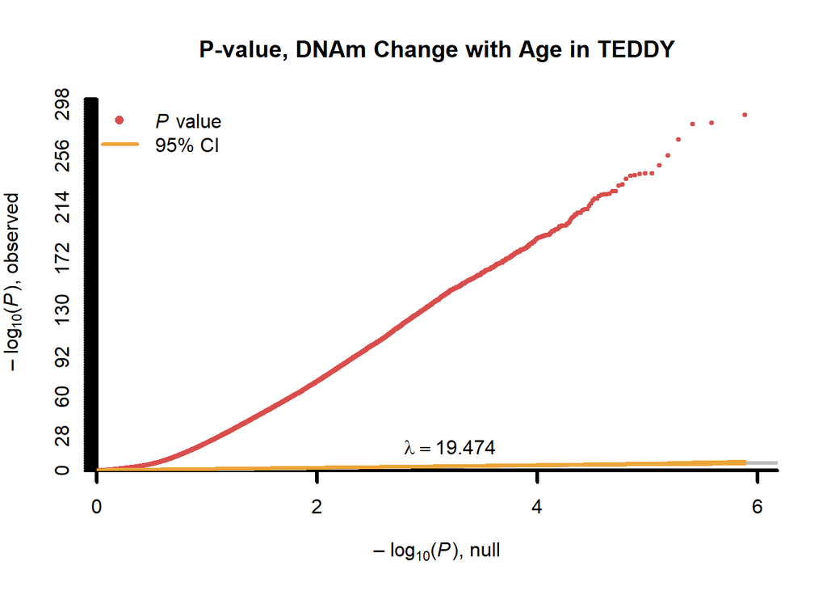

```r
qqPlotFast(age_teddy$is_fixed.sample_agedys.p.value, ismlog10 = FALSE)
title("P-value, DNAm Change with Age in TEDDY")
```

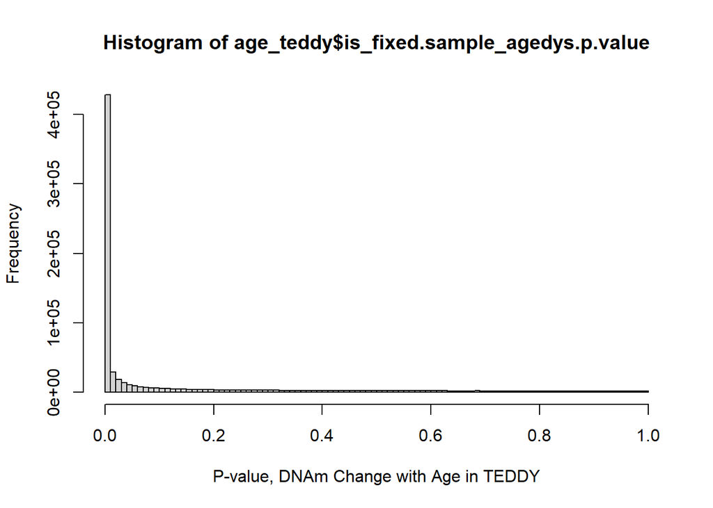

```r
hist(age_teddy$is_fixed.sample_agedys.p.value,
     breaks = 100,
     xlab = 'P-value, DNAm Change with Age in TEDDY')
```

```
## geom_pointdensity() using method='kde2d' due to large number of points (>20k). You may override this by setting method='neighbors'.
```

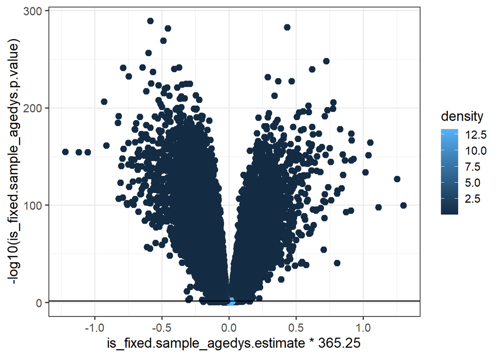

```r
ggplot(age_teddy, aes(x = is_fixed.sample_agedys.estimate*365.25, y = -log10(is_fixed.sample_agedys.p.value))) +
  geom_pointdensity(size = 2.5) +
  geom_hline(aes(yintercept = -log10(max(is_fixed.sample_agedys.p.value[which(age_sig==1)])))) +
  theme_bw(base_size = 14)
```

```r
addmargins(table(age_teddy$age_sig, age_teddy$age_dir))
```

```
##
##            -      +    Sum
##   0   176116 109634 285750
##   1   389000  88159 477159
##   Sum 565116 197793 762909
```

- Age has a large effect on DNAm. While genomic inflation is large, the expectation is that DNAm changes with age–what is the appropriate background expectation?
- Over half of CpGs have BH significant age effects (1 vs 0), the majority of which have an inverse relationship with age (age estimate is - vs. +)

Let’s do a quick sanity check on these age effects – how do the DNAm-age effect directions from TEDDY compare to the CpGs/weights used in the Horvath epigenetic clock (which performed best in Patrick Carry’s DAISY epigenetic aging work)?

The Horvath clock contains 353 CpGs, 320 of which are available in TEDDY. Only clock probes available in both datasets are included.

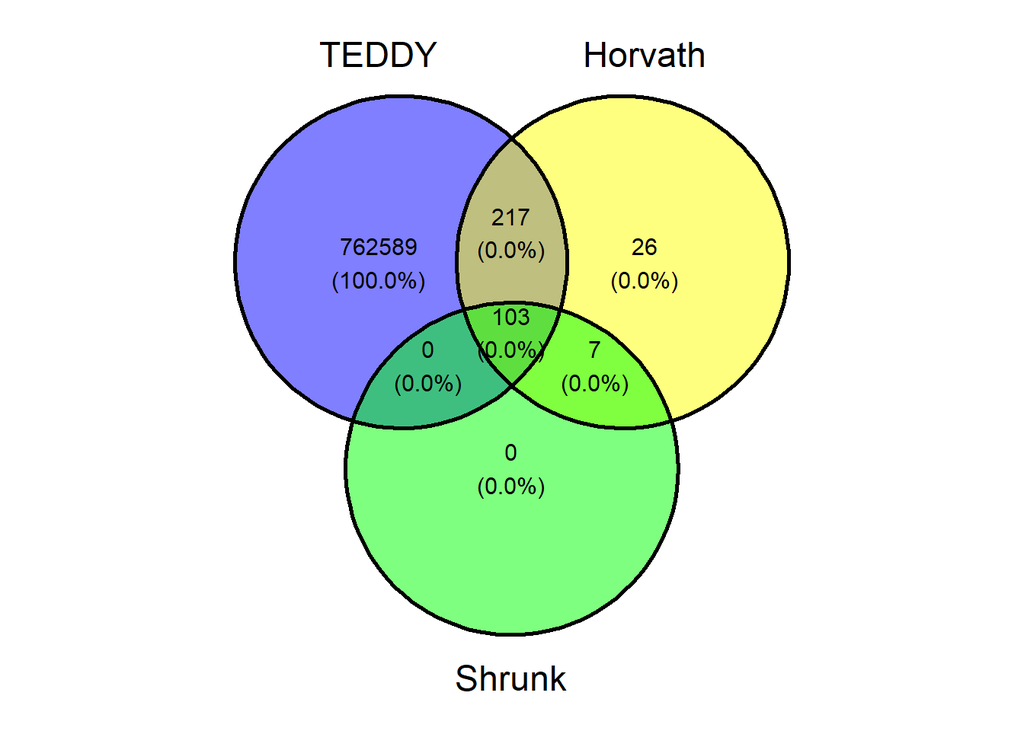

```r
ggvenn(list(TEDDY = age_teddy$CpG,
            Horvath = horvath$CpGmarker,
            Shrunk = horvath$CpGmarker[which(!is.na(horvath$CoefficientTrainingShrunk))]))
```

```r
age_clock_check = full_join(age_teddy[,c("CpG","is_fixed.sample_agedys.estimate","age_sig")], horvath[,c("CpGmarker","CoefficientTraining","CoefficientTrainingShrunk")], by = c("CpG" = "CpGmarker"))

summary(age_clock_check$is_fixed.sample_agedys.estimate[which(!is.na(age_clock_check$CoefficientTraining))])
```

```
##     Min.  1st Qu.   Median     Mean  3rd Qu.     Max.     NA's
## -0.00186 -0.00010 -0.00001 -0.00005  0.00003  0.00077       33
```

```r
summary(age_clock_check$CoefficientTraining)
```

```
##    Min. 1st Qu.  Median    Mean 3rd Qu.    Max.    NA's
##    -1.7    -0.2     0.0     0.0     0.1     3.1  762589
```

```
## Ignoring unknown labels:
## • fill : "Sig - TEDDY"
```

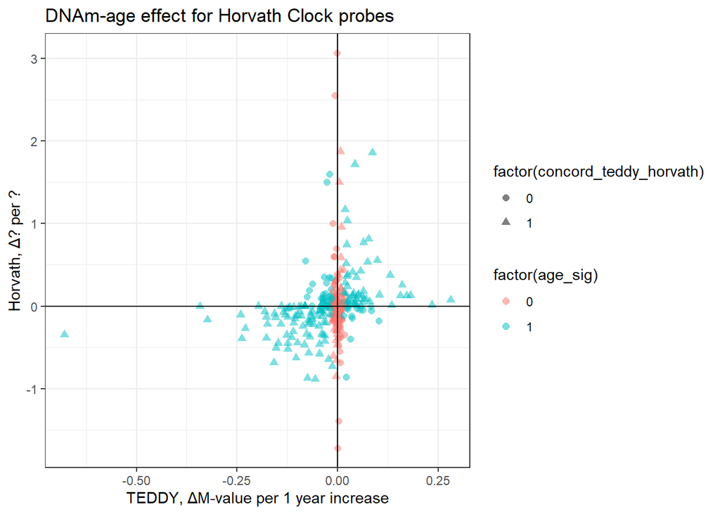

```r
# scales are very different - one is M-value per agedys increase,
# horvath is

age_clock_complete = age_clock_check[which(!is.na(age_clock_check$is_fixed.sample_agedys.estimate) & !is.na(age_clock_check$CoefficientTraining)),]

age_clock_complete$concord_teddy_horvath = ifelse(age_clock_complete$is_fixed.sample_agedys.estimate>0 & age_clock_complete$CoefficientTraining>0 | age_clock_complete$is_fixed.sample_agedys.estimate<0 & age_clock_complete$CoefficientTraining<0, 1, 0)

ggplot(age_clock_complete, aes(x = is_fixed.sample_agedys.estimate*365.25, y = CoefficientTraining, color = factor(age_sig), shape = factor(concord_teddy_horvath))) +
  geom_point(size = 2, alpha = 0.5) +
  scale_shape_manual(values = c(16,17)) +
  labs(x = "TEDDY, ΔM-value per 1 year increase",
       y = "Horvath, Δ? per ?",
       fill = "Sig - TEDDY",
       title = "DNAm-age effect for Horvath Clock probes") +
  geom_hline(yintercept = 0) +
  geom_vline(xintercept=0) +
  theme_bw()
```

```
## Ignoring unknown labels:
## • fill : "Sig - TEDDY"
```

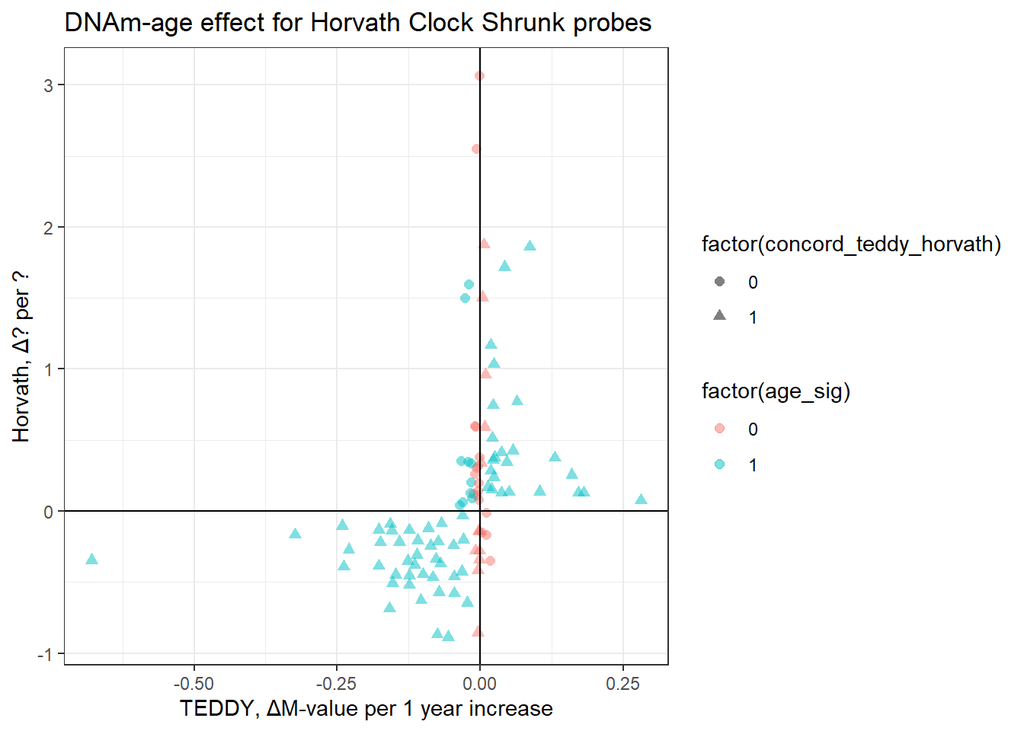

```r
age_clock_complete_shrunk = age_clock_complete[-which(is.na(age_clock_complete$CoefficientTrainingShrunk)),]

ggplot(age_clock_complete_shrunk, aes(x = is_fixed.sample_agedys.estimate*365.25, y = CoefficientTraining, color = factor(age_sig), shape = factor(concord_teddy_horvath))) +
  geom_point(size = 2, alpha = 0.5) +
  scale_shape_manual(values = c(16,17)) +
  labs(x = "TEDDY, ΔM-value per 1 year increase",
       y = "Horvath, Δ? per ?",
       fill = "Sig - TEDDY",
       title = "DNAm-age effect for Horvath Clock Shrunk probes") +
  geom_hline(yintercept = 0) +
  geom_vline(xintercept=0) +
  theme_bw()
```

How many Horvath full list Probes and “Shrunk” list probes have concordant age-effect in TEDDY, by significance?

```r
addmargins(xtabs(~age_sig + concord_teddy_horvath, age_clock_complete))
```

```
##        concord_teddy_horvath
## age_sig   0   1 Sum
##     0    71  61 132
##     1    48 140 188
##     Sum 119 201 320
```

```r
addmargins(xtabs(~age_sig + concord_teddy_horvath, age_clock_complete_shrunk))
```

```
##        concord_teddy_horvath
## age_sig   0   1 Sum
##     0    17  12  29
##     1    10  64  74
##     Sum  27  76 103
```

# **Age effects in Candidates**

Question: Does methylation at candidate CpGs of the maternal T1D effect change with age?

Restricting to just candidates, let’s examine the frequency of age significance and direction

```r
addmargins(table(age_teddy$age_sig[which(age_teddy$candidate==1)], age_teddy$age_dir[which(age_teddy$candidate==1)]))
```

```
##
##         -   + Sum
##   0    66  54 120
##   1    84  52 136
##   Sum 150 106 256
```

- More than half do change with age.

Let’s examine trajectories for 10 age-related candidates whose age effects are most extreme.

```r
getSpagPlot_colorSig = function(CpG, toPlot, var_color){
  anno = candidates[which(candidates$cpg==CpG), ]
  yLab = paste0(CpG, " (M value)")
  title = paste0(
    CpG, ", ", paste0(anno$CpG_chrm, ":", anno$pos),
    ifelse(anno$dmrid_red == "", "", paste0(", ", anno$dmrid_red)),
    ifelse(anno$UCSC_RefGene_Name == "", "", paste0(", ", anno$UCSC_RefGene_Name)))
  colnames(toPlot)[which(colnames(toPlot)==CpG)] = "CpG"
  sig_status <- age_teddy$age_sig[age_teddy$CpG == CpG]

  p = ggplot(data = toPlot, aes(x = (sample_agedys/365.25), y = CpG, group = maskid))+
    geom_line(alpha=0.4) +
    theme_bw()+
    xlab("Sample Age (Years)") +
    ylab(yLab)+
    labs(title=title)+
    theme(plot.title = element_text(size=7)) +
    facet_wrap(~as.factor(get(var_color)), ncol = 3)
  return(p)
}
```

```r
age = age_teddy %>% dplyr::filter(candidate==1 & age_sig==1) %>%arrange(desc(abs(is_fixed.sample_agedys.estimate))) %>% head(10)
```

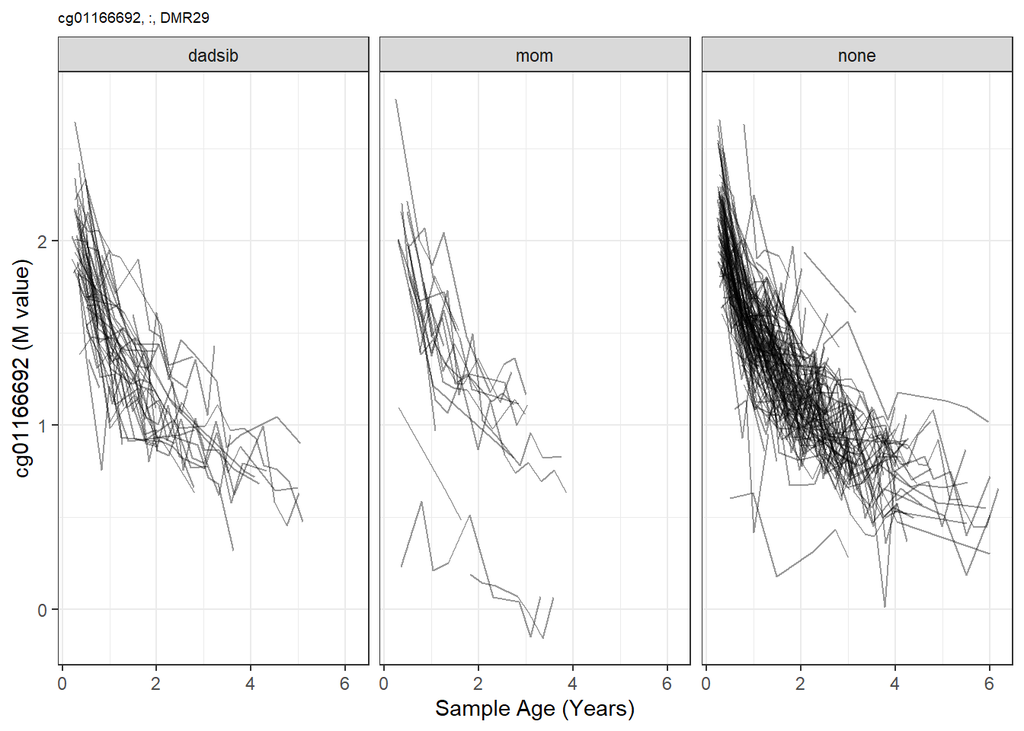

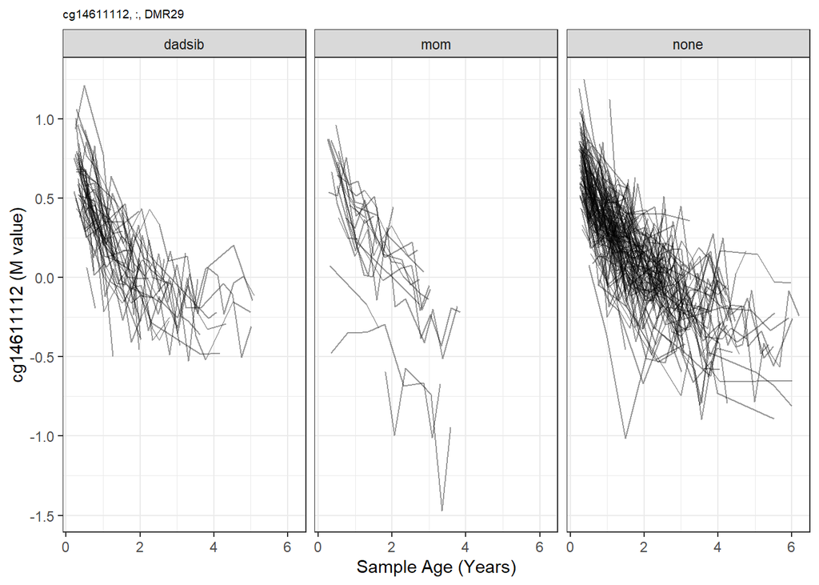

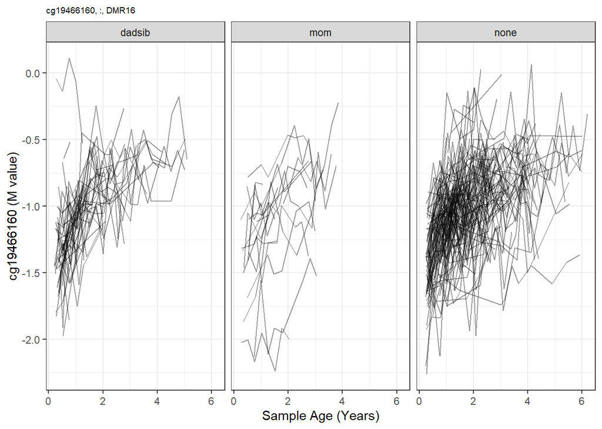

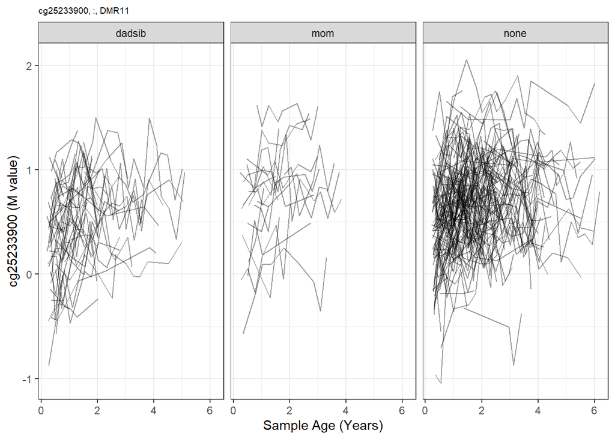

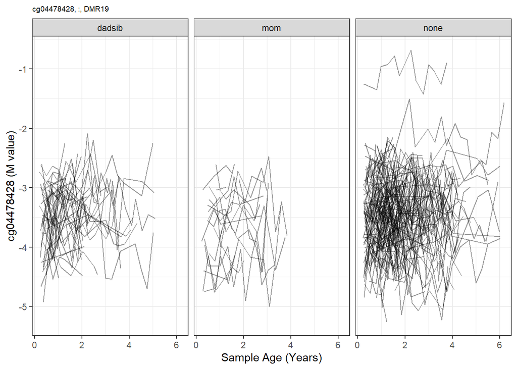

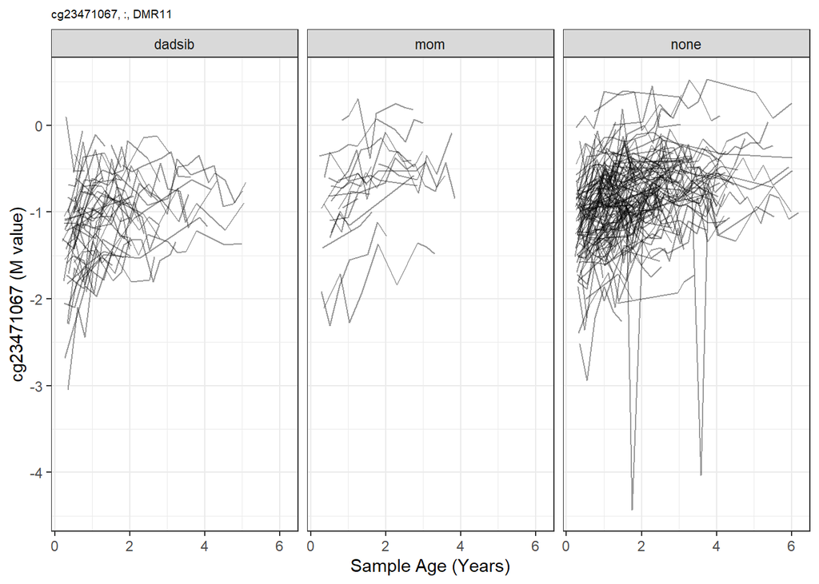

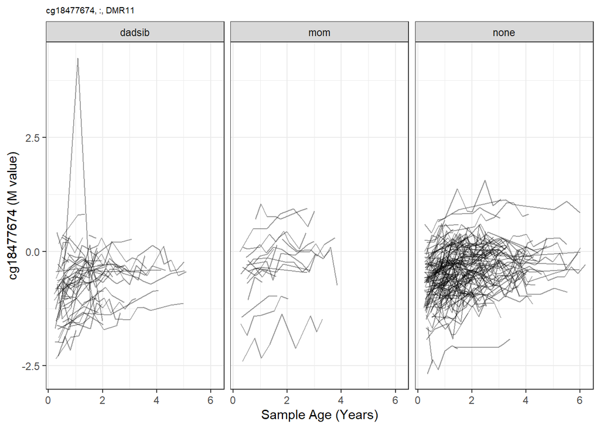

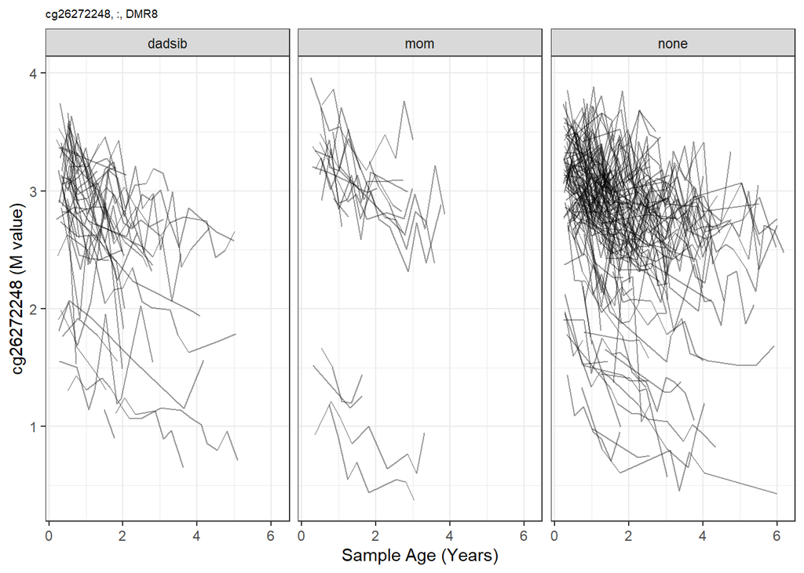

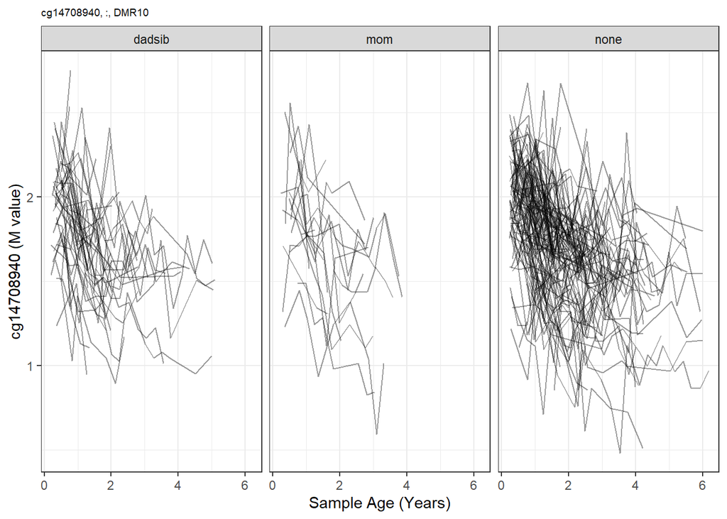

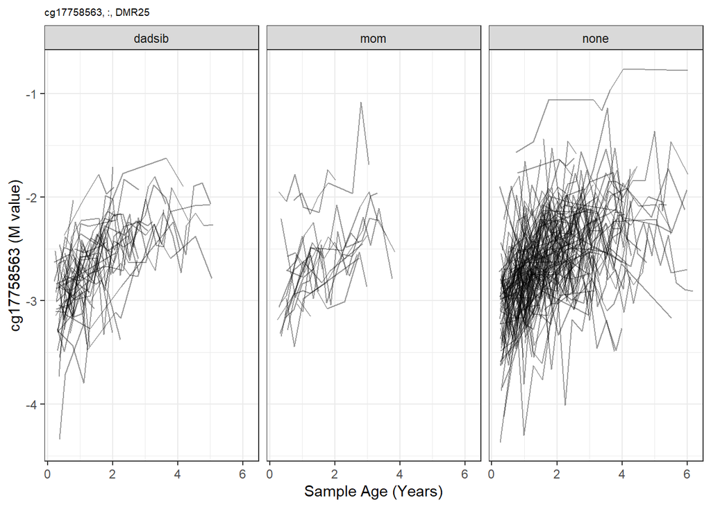

```r
dnam_me <- as.data.frame(dnam[rownames(dnam) %in% age$CpG,])
plot_me <- merge(pheno, t(dnam_me), by.x="rgName", by.y=0)
plot_me = left_join(plot_me, pheno_analysis[,c("maskid","fdr_3level","t1d")], by = "maskid")
plot_me = plot_me[which(plot_me$maskid %in% pheno_analysis$maskid),]

plots_me = lapply(age$CpG, function(a,b,c) {
  getSpagPlot_colorSig(a,b,c)}, b = plot_me, c = "fdr_3level")
marrangeGrob(grobs = plots_me, ncol = 1, nrow = 1, top = NULL)
```

# **DMR age-effect concordance**

Let’s investigate whether age effects tend to be concordant within DMRs. We summarized CpGs with significant age effects within each DMR by direction and mean.

```r
dmr_age = candidates %>% dplyr::filter(dmrid_red != "") %>% group_by(dmrid_red) %>% summarise(nprobe_age = n(),
                                                           age_dir = paste(age_dir, collapse = " "))

dmr_age_sig = candidates %>% dplyr::filter(dmrid_red != "" & age_sig==1) %>% group_by(dmrid_red) %>% summarise(nprobe_age_sig = n(),
                                                           dir_age_sig = paste(age_dir, collapse = " "),
                                                           npos_age_sig = sum(age_dir == "+", na.rm = TRUE),
                                                           mean_est_age_sig = mean(is_fixed.sample_agedys.estimate))

dmr_age = left_join(dmr_age, dmr_age_sig, by = "dmrid_red")
dmr_age$age_dir = NULL

dmr_age$pct_sig = round(dmr_age$nprobe_age_sig/dmr_age$nprobe_age*100,2)

dmr_age$pct_sig_pos = round(dmr_age$npos_age_sig/dmr_age$nprobe_age_sig*100,2)

kable(dmr_age)
```

| dmrid_red | nprobe_age | nprobe_age_sig | dir_age_sig | npos_age_sig | mean_est_age_sig | pct_sig | pct_sig_pos |
| --- | --- | --- | --- | --- | --- | --- | --- |
| DMR1 | 2 | 2 | + + | 2 | 0.0000949 | 100.00 | 100.00 |
| DMR10 | 4 | 4 | - - - - | 0 | -0.0001517 | 100.00 | 0.00 |
| DMR11 | 8 | 7 | + + + + + + + | 7 | 0.0002095 | 87.50 | 100.00 |
| DMR12 | 22 | 9 | + + + + - - - + + | 6 | -0.0000064 | 40.91 | 66.67 |
| DMR13 | 4 | 3 | + + + | 3 | 0.0001051 | 75.00 | 100.00 |
| DMR14 | 3 | 1 | + | 1 | 0.0000375 | 33.33 | 100.00 |
| DMR15 | 7 | 2 | + + | 2 | 0.0000555 | 28.57 | 100.00 |
| DMR16 | 4 | 4 | + + + + | 4 | 0.0002288 | 100.00 | 100.00 |
| DMR17 | 2 | 2 | - + | 1 | -0.0000027 | 100.00 | 50.00 |
| DMR18 | 4 | 2 | - + | 1 | 0.0001035 | 50.00 | 50.00 |
| DMR19 | 8 | 4 | - + + + | 3 | 0.0001170 | 50.00 | 75.00 |
| DMR2 | 8 | 1 | - | 0 | -0.0000425 | 12.50 | 0.00 |
| DMR20 | 4 | NA | NA | NA | NA | NA | NA |
| DMR21 | 2 | 2 | - - | 0 | -0.0000906 | 100.00 | 0.00 |
| DMR22 | 6 | 5 | - - + + + | 3 | 0.0000265 | 83.33 | 60.00 |
| DMR23 | 2 | 2 | + + | 2 | 0.0000507 | 100.00 | 100.00 |
| DMR24 | 4 | 4 | - + + - | 2 | -0.0000118 | 100.00 | 50.00 |
| DMR25 | 2 | 2 | + + | 2 | 0.0002285 | 100.00 | 100.00 |
| DMR26 | 6 | 1 | + | 1 | 0.0000497 | 16.67 | 100.00 |
| DMR27 | 2 | 1 | - | 0 | -0.0000383 | 50.00 | 0.00 |
| DMR28 | 2 | 1 | - | 0 | -0.0000795 | 50.00 | 0.00 |
| DMR29 | 2 | 2 | - - | 0 | -0.0005968 | 100.00 | 0.00 |
| DMR3 | 2 | 2 | - - | 0 | -0.0001231 | 100.00 | 0.00 |
| DMR30 | 7 | 5 | - - - - - | 0 | -0.0000833 | 71.43 | 0.00 |
| DMR31 | 9 | NA | NA | NA | NA | NA | NA |
| DMR32 | 6 | 1 | - | 0 | -0.0000478 | 16.67 | 0.00 |
| DMR33 | 2 | NA | NA | NA | NA | NA | NA |
| DMR4 | 2 | NA | NA | NA | NA | NA | NA |
| DMR5 | 7 | 2 | + + | 2 | 0.0001567 | 28.57 | 100.00 |
| DMR6 | 4 | NA | NA | NA | NA | NA | NA |
| DMR7 | 5 | 4 | + + - - | 2 | -0.0000042 | 80.00 | 50.00 |
| DMR8 | 3 | 3 | - - + | 1 | -0.0001433 | 100.00 | 33.33 |
| DMR9 | 4 | NA | NA | NA | NA | NA | NA |

# **Write Output**

We write out select columns for candidates only: age effect estimate, standard error, pvalue, and fdr/qvalue

```r
write.csv(x = age_teddy[which(age_teddy$candidate==1), c("CpG","is_fixed.sample_agedys.estimate","is_fixed.sample_agedys.std.error","is_fixed.sample_agedys.p.value","is_fixed.sample_agedys.fdr")], file = "data/results/manuscript/candidate_age_effects.csv", row.names = F, na="")
```